# Introduction

Airbnb is a platform in which people may be able to provide or obtain temporary lodging in homes that are not occupied at that time. This is relatively novel compared to the more conventional hotels that travelers would try to obtain lodging in. How people would perceive this industry and how their personal preference when choosing between the lodgings provided, however, is a concept that is not very familiar to us. In order to gain more insight into this issue, we looked into the Airbnbs in New York City, as this is a very popular traveling destination, to see if we can find some sort of association between personal preferences and the types of lodging or promotion that is provided of the lodging.

# Background:

The data used within this analysis contains information about the different listings provided on Airbnb. Those information ranges from the way the owners named their lodgings to the location or type of lodging provided. A more detailed description of the information provided will be shown below.

#### The different pieces of information are organized into columns, described as below. There are 16 variables within the dataset.

1. Listing ID: The unique identification number of each Airbnb represented in New York. Represented in the dataset as “id”.
2. Name: This is the name of Airbnb in New York. Represented in the dataset as “name”.
3. Host ID: The owner/host of the Airbnb has his/her own unique identification number. This is helpful to classify different Airbnb that are owned by a single host. Represented in the dataset as “host_id”.
4. Host Name: This is the name of the host/owner of the Airbnb. Represented in the dataset as “host_name”.
5. Neighbourhood Group: This includes the five major locations within New York City: Bronx, Brooklyn, Manhattan, Queens and Staten Island where the Airbnb is located Represented in the dataset as “neighbourhood_group”.
6. Neighbourhood: These are the different areas within the five major neighbourhoods in New York City where the Airbnb is located. Represented in the dataset as “neighbourhood”.
7. Latitude: This is the latitude of the Airbnb in New York Represented in the dataset as “latitude”.
8. Longitude: This is the longitude of the Airbnb in New York. Represented in the dataset as “longitude”.
9. Room Type: This tells about the Airbnb space type. Represented in the dataset as “room_type”.
10. Price: This is the price in dollars of living in the Airbnb for a single night. Represented in the dataset as “price”.
11. Minimum Nights: This is the minimum night the individual has to stay at the Airbnb. Represented in the dataset as “minimum_nights”.
12. Number of Reviews: This is the number of reviews the Airbnb has received. Represented in the dataset as “number_of_reviews”.
13. Last Reviewed: This includes the last date the Airbnb was reviewed. Represented in the dataset as “last_review”.
14. Reviews per month: This includes the mean number of reviews the Airbnb receives in a month. Represented in the dataset as “reviews_per_month”.
15. Host Count: This tells us about the number of Airbnbs owned per host. Represented in the dataset as “calculated_host_listings_count”.
16. Availability: This tells us about the number of days when Airbnb is available for booking. Represented in the dataset as “availability_365”.

#### Dataset

We got our dataset from Kaggle, which is an open source website used by many people for the purpose of data analysis. The URL link to our dataset is: https://www.kaggle.com/dgomonov/new-york-city-airbnb-open-data

#### Unusual factor to be aware of:

The data does not provide information on how many people have actually booked the lodging. The only data to reflect the number of people who had stayed there is the number of reviews it has received.

#### Background Information on questions posed:

To know what consumers consider when choosing between lodgings when choosing which Airbnbs to reside in, we tried to find which kind of Airbnbs travelers choose the most. In the data, we made some assumption to be able to obtain the data needed to answer our big question.

#### Assumptions made about the data:

1. We assume that the reviews can only be given by the individuals that have stayed in those Airbnbs. Since Airbnb would encourage people to give reviews after each stay, the number of reviews is directly proportional to the number of people that have stayed at that Airbnb.
2. We think that the airbnbs that have an extended period of availability, but have no reviews, or any latest review date would suggest that it is newly opened.

With the assumptions we made above, we went on to figure out the factors that influence the traveler’s decisions, and then we went on to look at how the owners of Airbnbs have adjusted their advertising strategy in reflection of the newly adjusted preferences of the consumers.

### Map Of New York City

[figure not shown]

# Analysis:

The analysis of our data in divided into three parts. Each part of the analysis will include R techniques, numerical as well as graphical data.

# PART 1

For the first part, we wanted to find the general idea of how the characteristics mentioned in the names of the Airbnbs is related to the number of people staying in them. Then we tried to find out the other features the Airbnbs with the examined characteristics possess to find out the correlation and causation of those Airbnbs being popular.

As we can see from the data set the names of the Airbnbs include specific words that convey important characteristics of the Airbnb. For example words like large, big, accommodations, duplex, huge, etc would fall into the category of ‘spacious’ Airbnbs. So we wanted to find the preference of how people would like to name their Airbnbs. We will first find out the different types of characteristics that could be found from the data. Below are the characteristics that we have concluded over the dataset.

1. ‘comfortable’, ‘sunny’, ‘bliss’ are thought as cozy Airbnbs
2. ‘brand new’, ‘fresh’, are thought as clean Airbnbs
3. ‘peaceful’, ‘private’ are thought as quiet Airbnbs
4. ‘large’, ‘big’, ‘accommodations’, ‘duplex’, ‘huge’, ‘entire’ are thought as spacious Airbnbs
5. ‘central’, ‘near’, ‘trains’, ‘minute’, ‘midtown’, ‘downtown’, ‘brownstone’, ‘Manhattan’, ‘Brooklyn’, ‘bkln’ are thought as Airbnbs that emphasize location.
6. ‘cute’, ‘lovely’, ‘artist’, ‘art’, ‘wonderful’, ‘charming’, ‘gorgeous’, ‘authentic’ are thought as beautiful Airbnbs.
7. Airbnbs using the word ‘furnished’ in their name are considered to be under furnished category
8. ‘affordable’, ‘cheap’, ‘low $’ are thought of as cheap Airbnbs
9. ‘luxurious’ , ‘luxury’ are thought of as luxury Airbnbs.

The words above were found by picking up at random 100 names of Airbnbs using a seed.

Since we have all this information we would want to know how the proportion of Airbnbs whose names contain the above mentioned characteristic words. From this we would also be able to know which the mostly used characteristic words are.

#### To display this visually, we created a chart.

```
## # A tibble: 100 x 1
##     name
##     <chr>
##   1 Spacious and peaceful Park Slope apartment!
##   2 Summer in the City
##   3 1B-1B apartment near by Metro
##   4 Spacious studio in Upper East Side
##   5 Gorgeous Apt close to ❤️Times Square❤️
##   6 Greenpoint room
##   7 Spacious East Village/Alphabet City Apt
##   8 Gorgeous Brooklyn Bedroom with Luxury Decor
##   9 1 Bedroom Heart of Financial Dist
##  10 Private Room near Columbia University
##  11 Bright Brooklyn One Bedroom
##  12 Factory Converted Studio Loft in GP
```

[output cut: 88 more lines]

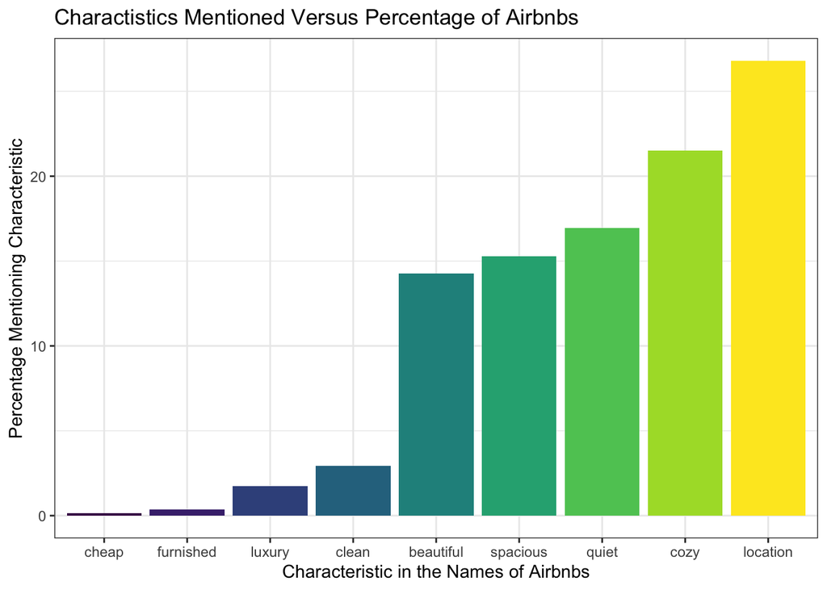

Once we have concluded these characteristics, we should see how mentioning these characteristics in the Airbnb names would affect the number of reviews they receive. Here we make an assumption that Airbnbs can only be reviewed by individuals who have actually stayed there. Therefore, the number of reviews it receives indicates the number of people who have stayed in that Airbnb. One downfall of this dataset regards the uncertainty of whether the reviews of the Airbnb are good or bad. So for the purpose of our interpretation, we have considered all of them as positive. However, it would have been better if we had the actual reviews given by the consumers or the number of consumers who have stayed in those Airbnbs.

## Do characteristics mentioned in the name of the Airbnbs affect their review count?

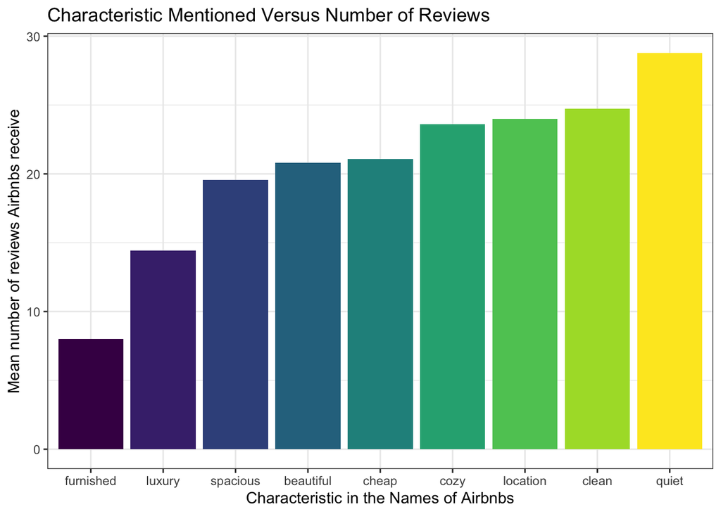

Inferences:

In New York City, people prefer to stay in “quiet” Airbnbs. We think this may be because people value this characteristic in face of the loud and fast-paced nature of the city.

However, there may be other factors that make the Airbnbs mentioning this sort of characteristics to be so attractive to the consumers. Therefore, we started looking at different factors of Airbnbs that may affect the way that may influence a person’s decision as to where to stay.

## Since airbnbs with characteristic words of quiet are reviewed the most , it would be interesting to see how their prices compares to the prices of other airbnbs in New York City.

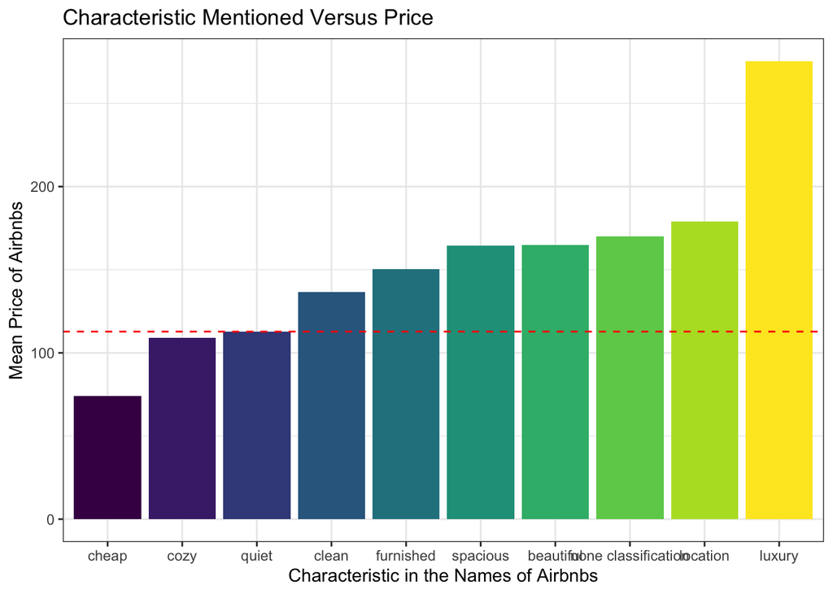

As we can see from the above graph, the mean price of the Airbnbs that are characterized as quiet are on the lower end on the price, being the characteristic with the third cheapest price. We would suspect the reason for this is related to the location and the type of rooms that these Airbnb offer. It is reasonable to assume that quiet Airbnbs would usually provide cheaper room types and tend to be located at cheaper locations. Whether or not they are due to inherent nature or due to choice of owners of these Airbnbs would need further test to be known clearly. However, the hypotheses of possibilities are still able to be formed from analysis.

To confirm our inference, we tried to find the relationship between type of room and the Airbnbs that mentions the characteristic ‘quiet’ in their name first. In the data set we have three room types: Entire homes or apartments, Private rooms, and Shared rooms. Since the price of Airbnbs with the characteristic words of quiet are on the lower end we would expect that these Airbnbs would offer more rooms than homes or apartments.

## Do owners of Airbnbs who have characteristics words of quiet in the names offer more of specific room type?

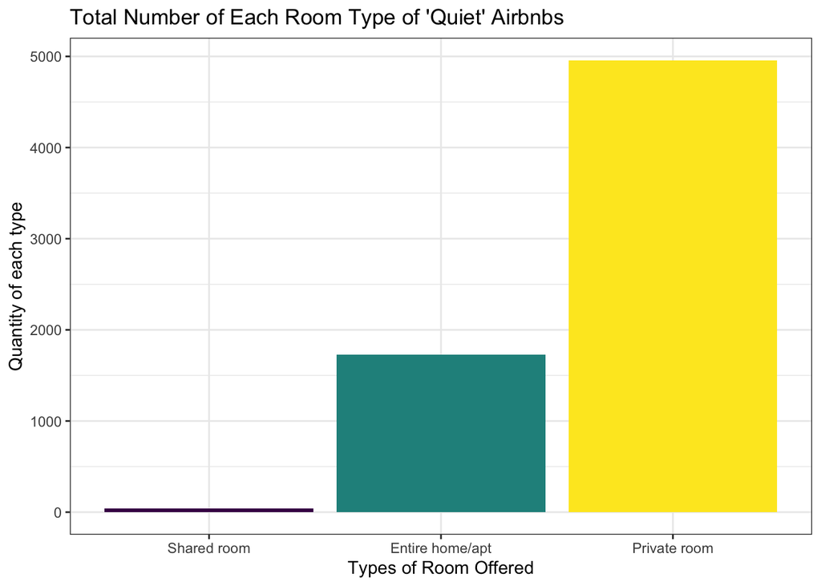

What we see from the graph is that Airbnbs with quiet characteristics offers more private rooms rather than any other type. This makes sense as quiet rooms generally afford more privacy and relatively smaller size of room compared to apartments would both result in the low price of quiet rooms.

Another aspect of the graph is that airbnbs with characteristic words of quiet in their names hardly have Airbnbs with shared rooms even though shared rooms should cost less. This would make sense as shard rooms, albeit cheaper, would mitigate the peace and quiet of the traveler residing in the room. This is further evidence supporting our claim that quiet Airbnbs offer more private rooms than the other types of rooms.

After looking at the room type, we turn to analyze our guess of the second reason for these rooms to be so cheap, being that they would be located at cheaper neighbourhoods within New York City.

# Does the location relates, if at all, with the price of the airbnb?

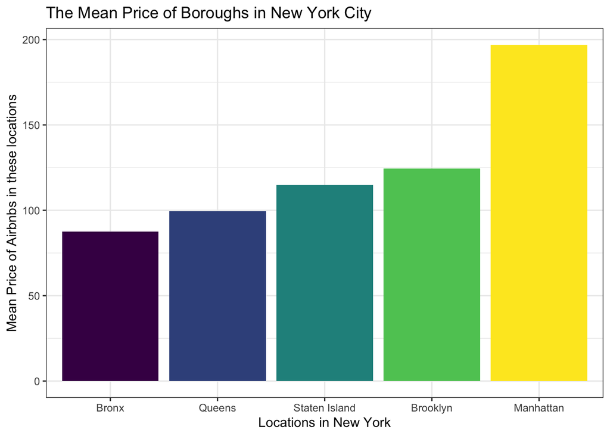

As seen in the graph, we can conclude that the airbnbs in New York that are located in Manhattan as significanly more expensive than the airbnbs present elsewhere.The neighbourhood apart from manhattan have nearly the same mean price. This seems to suggest that locations in New York would effect the price, with the price of being located in Manhattan having major impact on the price of the lodging.

In order to prove whether the the mean price of the airtbnbs in Manhattan is statistically different from the mean price of any other boroughs, we first used the Analysis of Variance test(ANOVA).

## Analysis of Variance Test

Analysis of variance is a collection of statistical models and their associated estimation procedures used to analyze the differences among group means in a sample. In this case, we wanted test if the mean price of the different locaitons in New York are different.

The null hypothesis here is that the mean price of airbnbs in each borough is the same.

The alternative hypothesis is that the mean price of the airbnbs in each borough is different.

[output not shown]

Next, we used 4 individual t tests to compare the mean price of the airbnbs in Manhattan with the mean price of airbnbs in different boroughs.

## T-Tests

The algorithm used in t-tests is to compare the two means to see if the difference between the two is statistically significant. Since we are trying to compare the mean price of Airbnbs in different boroughs of New York City, this type of testing seems to be very fitting.

```
t_test = function(mean1, sd1, total1, mean2, sd2, total2)
{
  z = (mean1 - mean2) / sqrt((sd1*sd1 / total1) + (sd2*sd2 / total2))
  if (total1 > total2) {
    df = total2 - 1
  }
  else { df = total1 - 1 }

  p_val = pt(z, df)
  return (p_val)
}
```

#### First t-test:

Comparing the mean price of airbnbs in Manhattan to the mean price of airbnbs in Brooklyn.

The null hypothesis here is that the mean price of the airbnbs in Manhattan is the same as the mean price of the airbnbs in Brooklyn.

The alternative hypothesis is that the mean price of the airbnbs in Manhattan is not the same as the mean price of the airbnbs in Brooklyn.

[output not shown]

#### Second t-test:

Comparing the mean price of airbnbs in Manhattan to the mean price of airbnbs in Queens.

The null hypothesis here is that the mean price of the airbnbs in Manhattan is the same as the mean price of the airbnbs in Queens.

The alternative hypothesis is that the mean price of the airbnbs in Manhattan is not the same as the mean price of the airbnbs in Queens.

[output not shown]

#### Third t-test:

Comparing the mean price of airbnbs in Manhattan to the mean price of airbnbs in Bronx.

The null hypothesis here is that the mean price of the airbnbs in Manhattan is the same as the mean price of the airbnbs in Bronx.

The alternative hypothesis is that the mean price of the airbnbs in Manhattan is not the same as the mean price of the airbnbs in Bronx.

[output not shown]

#### Fourth t-test:

Comparing the mean price of airbnbs in Manhattan to the mean price of airbnbs in Staten Island.

The null hypothesis here is that the mean price of the airbnbs in Manhattan is the same as the mean price of the airbnbs in Staten Island.

The alternative hypothesis is that the mean price of the airbnbs in Manhattan is not the same as the mean price of the airbnbs in Staten Island.

[output not shown]

##### Findings from the first t-test:

The p-value we got from performing such test is 8.243e-200, which is almost 0. We have strong evidence against the null hypothesis and in favor of the alternative hypothesis.

##### Findings from the second t-test:

The p-value here was 1.15e-215, which is almost 0, also strong evidence against the null hypothesis and in favor of the alternative hypothesis.

##### Findings from the third t-test:

The p-value here was 7.124e-137, which is almost 0, also strong evidence against the null hypothesis and in favor of the alternative hypothesis.

##### Findings from the fourth t-test:

The p-value here was 1.56e-8, which is almost 0, also strong evidence against the null hypothesis and in favor of the alternative hypothesis.

#### Conclusions from the series of t-test:

We can conclude from the series of t-tests that Manhattan has different mean price than any other borough in New York City, which was seen from the p-values in each case which was usually in the hundreds of negative power of the scientific notation. Furthermore, from the graph displaying the mean price of all the boroughs in New York City, we saw that Manhattan had a higher price than any other place in New York City. Hence, we can say with statistical proof that the airbnbs in Manhattan have a higher mean price than airbnbs in different boroughs in New York City.

## Which boroughs of new york are the airbnbs that have chraracteristics words of quiet in their name located ?

[figure not shown]

From the graph above, we can see that most of the Airbnbs characterized as quiet are located in Brooklyn which makes sense as Brooklyn is one among the comparatively cheaper neighbourhoods in New York. This is an important finding as previously we found out that Airbnbs with the quiet characteristic had one of the lowest prices and this can only make sense if they were located in areas that have low living prices.

However, we also noticed that the second highest number of Airbnbs characterized as quiet is located in Manhattan. This seems to be contradictory to our findings of quiet Airbnbs being cheap. So we wanted to know the price distribution of neighbourhoods in Manhattan, and how that may have lowered the price of these Airbnbs.

After we have looked at the neighborhoods within Manhattan, we wanted to know if the room types offered by these Airbnbs also would contribute to lower price as we have found the general trend of Airbnbs characterized as quiet to be.

After looking at the discrepancy of Manhattan, we then take a further look into Brooklyn, which is the borough with the most Airbnbs characterized as quiet, to get a better understanding of the general features of these Airbnbs. We looked at this in the same way we did for Manhattan because we wanted to see if the same features hold true for the two boroughs.

## Which neighbourhood in Brookyln are the airbnbs with the quiet characteristic words located?

| Neighbourhood | Bedford-Stuyvesant |
| --- | --- |
| Total Number | 626 |

## Let us rank the Brooklyn neighborhoods from most to least expensive in terms of average price.

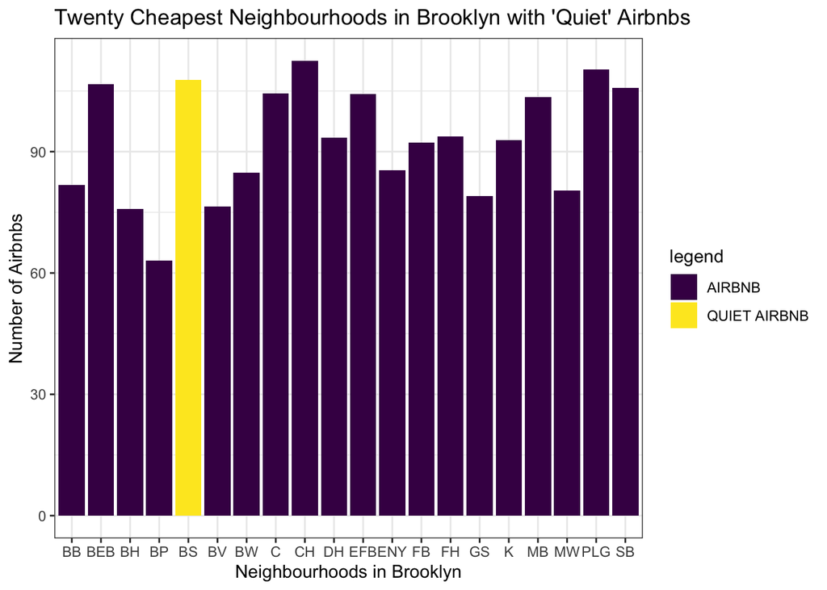

We found out that the neighborhoods in Brooklyn with the most quiet chartacteristic airbnbs are located in Bedford Stuyvesant. Now, to see the relation between the living price of these neighborhoods and the quiet airbnbs, we find the average living cost of the neighborhoods in Brooklyn. If we would find that the price of the quiet neighbourhoods are among the locations in Brookyln that have the lowest average price then this finding would serve as evidence that quiet airbnbs mainly target locations with cheap living expenses in order to keep its price low. So we made a graph showing top 20 cheapest neighborhoods in Brooklyn, and tried to see if Bedford-Stuyvesant would be among them.

From the graph above, we found out here that Bedford-Stuyvesant is among the 20 neighbourhoods in Brooklyn that are ranked the lowest in terms of their living expenses. This can be shown in the graph with abbreviation of the names of the top 20 cheapest neighborhood in Brooklyn. It is highlighted in yellow to show that it has a large amount of quiet Airbnbs. This finding has provided us with evidence that shows quiet Airbnbs are mainly locations in cheap places for the price of which to be so low.

Since most the airbnbs with quiet characteristics are present in these neighborhoods and these neighborhoods have relatively cheaper locations in Brooklyn, it would be interesting to find the number of individual room types in Bedford-Stuyvesant.

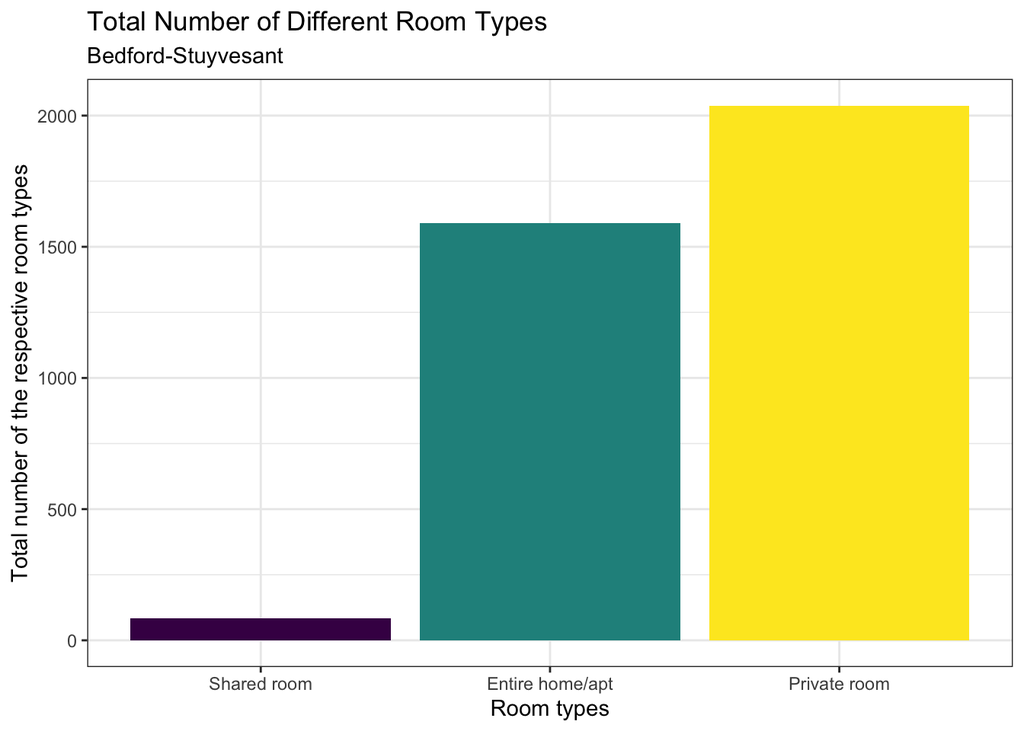

So now let’s connect all the findings. We wanted to know about the characteristic that people favor in Airbnbs,then we wanted to find the other features of the Airbnbs with these characteristic may also contribute to people’s preference, or if those are also part of the contributing factor to enhance this characteristic. First we found out that the Airbnbs that have the characteristic words of quiet were reviewed the most, which means that most people stayed at these Airbnbs. After which, we found out that the mean price of the Airbnbs that have the characteristic words of quiet are on the lower end on the living expenses in New York. To verify this we found that the living expense of locations in New York, from where we learnt that Manhattan’s living expenses was significantly higher than the other locations, while the other neighbourhoods have more or less that same living expenses. Moving on we found that most quiet Airbnbs are located in Brooklyn, which suggests that if quiet Airbnbs are cheaper then they must be located in relatively cheaper locations in New York like Brooklyn. We went on to find if the same pattern follows for neighborhoods in Brooklyn, and we found out that the most quiet Airbnbs are located in Bedford-Stuyvesant, which is among the locations in Brooklyn that have low living expenses. Evidence to our finding is that the most common types of Airbnbs in Bedford-Stuyvesant are the ones that have a private room type, which are representative of quiet rooms.

In conclusion, we found out from the data that people prefer to stay in Airbnbs that are characterized as quiet. These Airbnbs are also one of the cheapest types of airbnbs in New York and they are mostly located in Bedford Stuyvesant, a neighbourhood in Brooklyn, which indicates that location may also be a contributing factor for people to favor these Airbnbs.

# Part II

From Part I, we can conclude that Manhattan certainly has a higher price than all the other places within New York City. Since this location sticks out so much, we decided to do a bit more digging into it. In particular, we wanted to know the relation between the price that people are willing to pay and the location that these Airbnbs are at.

So we are analyzing the extent to which people feel it’s worth it to spend high amounts of money on expensive Airbnbs. For this question we will be targeting the individuals that are wealthy and the closest way to predict that in our case is to just focus our attention on the Airbnbs in Manhattan. The reason behind this is that as we found out previously Manhattan has the significantly higher prices for Airbnbs so the individuals who choose to live in Manhattan need to be affluent.

## What are the most expensive locations in the Manhattan?

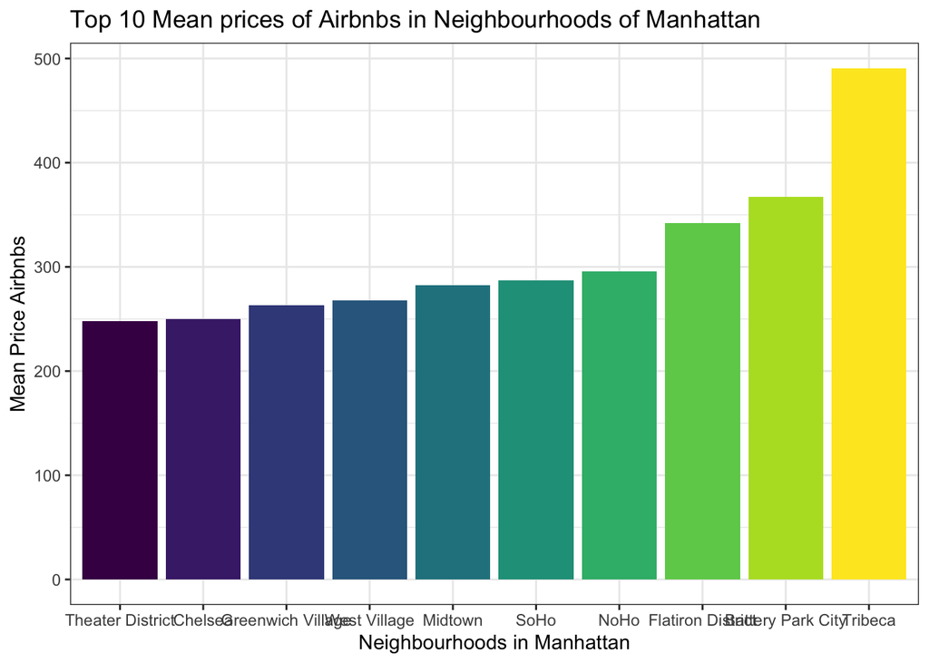

From the graph above, we found out that Tribeca is the neighborhood in Manhattan that has significantly higher average price of airbnbs followed by the Battery Park City.

## What are the average number of reviews these neighbourhoods in Manhattan receive? This would give us the idea of the number of people visiting the airbnbs in that region

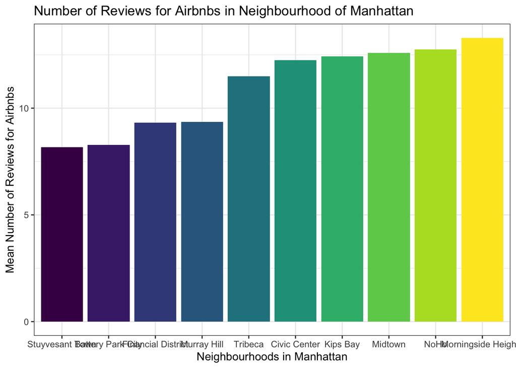

# PART III

To know more about the types of Airbnbs owners would be willing to provide, we wanted to know the status quo, so we conducted analysis that looks into the newly opened Airbnbs within New York City. Since it is more possible to believe that people will open new Airbnbs if there is reason to believe that the market in that region is profitable and are in demand, we believe that looking into the new Airbnbs opened would provide us not only with insight as to the kind of Airbnbs that owners like to provide, but also further show the preferences of the people choosing lodgings.

Asumption made with this question : We think that the airbnbs that are very available, but have no reviews, or any latest review date would suggest that it is newly opened. This is because there is reason to believe that if a new Airbnb is opened for most of the year, the likelihood of having not one single customer to leave review is highly unlikely. So we think they should be newly opened as that would provide the explanation that people were not able to provide reviews yet.

The condition we used to filter out all the observations that could potentially be new airbnbs are that these airbnbs have no reviews per month, they have no last review date and their availability throughout the year is more than hundred days.

## How many new Airbnbs have been opened recently?

```
## [1] 3401
```

We found that there are 3401 Airbnbs that are recently opened.

With these 3401 Airbnbs, we wanted to know if they are different from the previously opened ones, to see if the preferences of people have changed, or if owners have adjusted more to the taste of the consumers.

In order to do so, we needed to do similar analysis as before, so we looked at the characteristics that the new Airbnbs preferred to mention in their names.

## What characteristics do new airbnbs include?

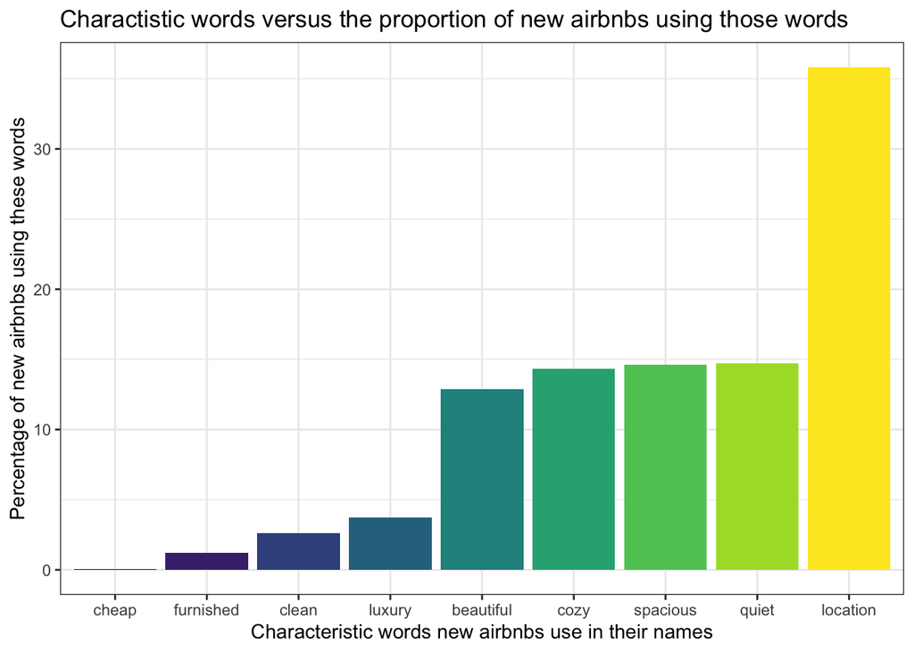

From the graph above, we see the staggering amount of mention of location. Although locations were also mentioned the most in the previous Airbnbs, now the amount is just towering over all the other characteristics, as oppose to the characteristics mentioned being more evenly distributed among the Airbnbs.

With evidence of this new preference among owners to name their Airbnbs, we thought it may be because people liked to choose Airbnbs that are in a specific location now. So we wanted to know where these new Airbnbs are located.

## In which neighbouhood are the new airbnbs being established in contrast to the airbnbs that where already present ?

[figure not shown]

We can infer from the graph that new Airbnbs opening in Manhattan has a significantly higher percentage than those of any other places. However, by comparing the percentage of Airbnbs already existed, there were almost equal percentages of Airbnbs in Manhattan and in Brooklyn. What we can infer from this is that nowadays owners of new Airbnbs tend to open Airbnbs in Manhattan.

So as to know more about the implications of the new Airbnbs in Manhattan, we took another look at the characteristics mentioned of the new Airbnbs in Manhattan to see if the pattern deviates much from the previously opened ones. If they mention the location a lot more, we can then conclude that people may just like to open in Manhattan much more than other places to account for the deviation of characteristics mentioned in general of the new Airbnbs as oppose to the previous ones.

## What are the other characteristics mentioned in new airbnbs in Manhattan?

[figure not shown]

From the above graph we can see that new airbnbs are using more “location” words in contrast to the existing Airbnbs. This may be because more Airbnbs are opening in Manhattan. Since Manhattan is a very popular tourist destination, it would make sense that people would prefer accommodations that emphasize location. Lots of Airbnb openings in Manhattan may also be influenced by the relative high prices, since they would want to generate more revenues.

# Discussion

We looked at the characteristics, locations, and prices of the Airbnbs provided and how that would affect a person’s choice in choosing the Airbnbs to stay in.

From our findings above, we found that people generally like to stay in quiet rooms in New York City, which are mostly located in Brooklyn. People who stay in Airbnbs do not enjoy splurging on overly expensive places to stay in, and prefers affordable places instead. And that recent interest in location has shifted to Manhattan, with much more lodging being provided and people willing to go there.

From these findings, we can draw a general profile of the group that seeks Airbnb accommodations to be frugal and prefers privacy and calm surroundings. We can also draw a general profile of the group that provides Airbnb accommodations to be cunning business people who provide accommodation according to the consumer’s preferences.

Potential short-coming of the analysis arise from two parts, one is that the information we gathered is based on the number of reviews that these Airbnbs have received. However since we are not able to know the quality of these reviews, how genuine these reviews are, or even whether or not these reviews are positive, it is very hard for us to conclude the actual preference of people with Airbnbs. This is also a problem when we were trying to evaluate the newly opened Airbnbs the base of our analysis was based on an assumption we made of the types of Airbnbs that resemble newly opened ones. In order to resolve this issue, we could go on the web in search for datasets that contains more of the information needed, as in the positive or negative reviews or number of people staying the Airbnb or the number of new Airbnbs that opened, to add to our original dataset in order to improve the accuracy of our inferences.

Another shortcoming of our analysis is the lack of statistical tests to test the accuracy of our inferences. However due to the magnitude of our analysis and our lack of time, we were not able to attribute much time into those. If given more time, we should design statistical tests to test the accuracy of our claims, such as how strong the correlation between low price and the characteristically quiet Airbnbs are in certain regions.

So in general, we found that the price, location, and characteristics of the accommodation are all factors that influence people’s choice of lodging. People are able to choose accommodations that fit their preference, and that owners of Airbnbs would work to meet these preferences. So Airbnb is indeed a platform that is very efficient, and brings much benefit to the people who use it. We believe that this is a study worth going deeper in if given time, as knowing the preferences of people would help owners make better decisions when providing accomodation so that there would be more optimal choices provided for people seeking a place to stay.